# Webscraping Open Secrets:

## A Silver Sloths Investigation

## How often does the candidate who raised more money win a race?

|  | more | sum | mean |
| --- | --- | --- | --- |
| 0 | False | 47 | 0.102397 |
| 1 | True | 384 | 0.882759 |

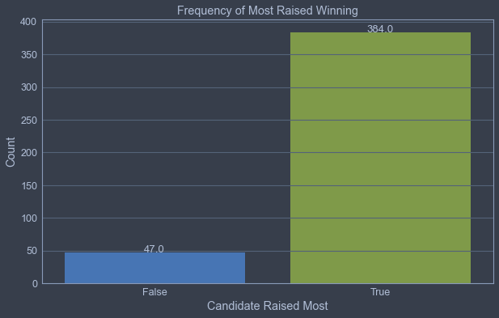

Candidates who raised the most money win their elections 88% of the time based on the data from the 2020 House of Representatives elections.

## How often does the candidate who spent more money win a race?

|  | more | sum | mean |
| --- | --- | --- | --- |
| 0 | False | 50 | 0.108932 |
| 1 | True | 381 | 0.875862 |

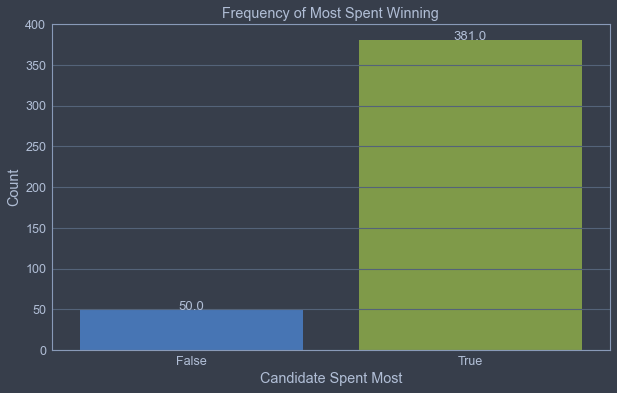

Candidates who spent the most money also win their elections 88% of the time based on the data from the 2020 House of Representatives elections.

## Does the difference between either money raised or money spent seem to influence the likelihood of a candidate winning a race?

```
                 Generalized Linear Model Regression Results
==============================================================================
Dep. Variable:                 winner   No. Observations:                  894
Model:                            GLM   Df Residuals:                      892
Model Family:                Binomial   Df Model:                            1
Link Function:                  logit   Scale:                          1.0000
Method:                          IRLS   Log-Likelihood:                -567.13
Date:                Sat, 23 Oct 2021   Deviance:                       1134.3
Time:                        09:54:16   Pearson chi2:                 1.03e+03
No. Iterations:                     5
Covariance Type:            nonrobust
==============================================================================
                 coef    std err          z      P>|z|      [0.025      0.975]
------------------------------------------------------------------------------
const         -0.6842      0.096     -7.147      0.000      -0.872      -0.497
raised      3.813e-07   4.57e-08      8.336      0.000    2.92e-07    4.71e-07
==============================================================================
```

```
                 Generalized Linear Model Regression Results
==============================================================================
Dep. Variable:                 winner   No. Observations:                  894
Model:                            GLM   Df Residuals:                      892
Model Family:                Binomial   Df Model:                            1
Link Function:                  logit   Scale:                          1.0000
Method:                          IRLS   Log-Likelihood:                -581.62
Date:                Sat, 23 Oct 2021   Deviance:                       1163.2
Time:                        09:54:16   Pearson chi2:                     955.
No. Iterations:                     5
Covariance Type:            nonrobust
==============================================================================
                 coef    std err          z      P>|z|      [0.025      0.975]
------------------------------------------------------------------------------
const         -0.5552      0.091     -6.076      0.000      -0.734      -0.376
spent       3.195e-07   4.39e-08      7.283      0.000    2.34e-07    4.05e-07
==============================================================================
```

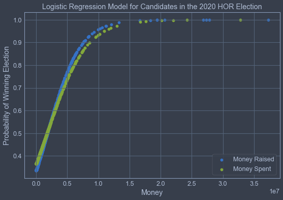

## How often does the incumbent candidate win a race?

| winner incumbent | True | False |
| --- | --- | --- |
| True | 0.96114 | 0.03886 |
| False | 0.11811 | 0.88189 |

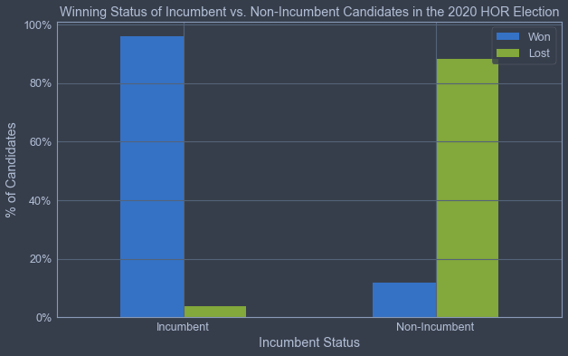

Based on the 2020 House of Representative election data, incumbent candidates are highly likely to be re-elected. 96% of incumbent candidates from the 2020 House of Representatives elections were re-elected.

On the other hand, it is very unlikely for a non-incumbent candidate to win their race. Only 12% of non-incumbent candidates from the 2020 House of Representatives elections won their race.

## Can you detect any relationship between amount of money raised and the incumbent status of a candidate?

### Histogram

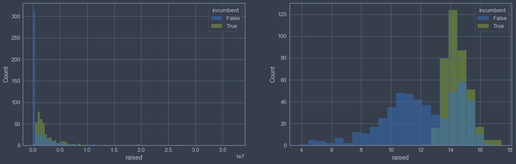

### Scatter, Log-Scatter, and Point plot

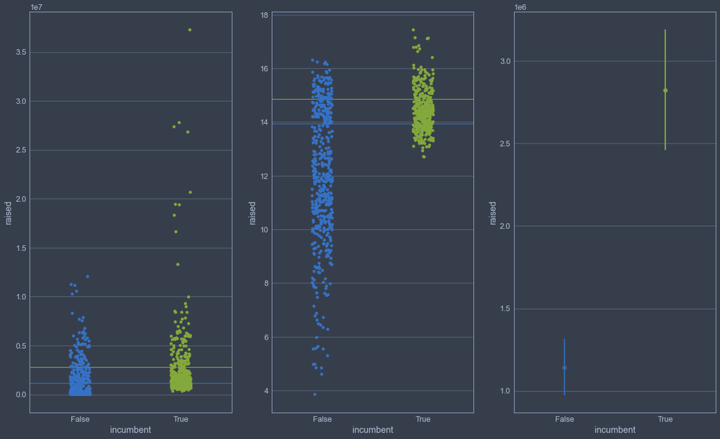

### Linear Models: Base Constant and Raised vs Incumbent

Here we construct a base model for comparative reference.

```
                 Generalized Linear Model Regression Results
==============================================================================
Dep. Variable:                 raised   No. Observations:                  894
Model:                            GLM   Df Residuals:                      893
Model Family:                Gaussian   Df Model:                            0
Link Function:               identity   Scale:                      9.1565e+12
Method:                          IRLS   Log-Likelihood:                -14609.
Date:                Sat, 23 Oct 2021   Deviance:                   8.1767e+15
Time:                        09:54:19   Pearson chi2:                 8.18e+15
No. Iterations:                     3
Covariance Type:            nonrobust
==============================================================================
                 coef    std err          z      P>|z|      [0.025      0.975]
------------------------------------------------------------------------------
const       1.866e+06   1.01e+05     18.434      0.000    1.67e+06    2.06e+06
==============================================================================
 Base AIC: 29219.92130876732
```

Here we construct the linear regression model. Note that the AIC is better (lower) than the base model's, if only slightly. You can't really make a good prediction of value from this model, but, based on earlier results, you can expect the incumbent to raise more money than the challenger.

```
                 Generalized Linear Model Regression Results
==============================================================================
Dep. Variable:                 raised   No. Observations:                  894
Model:                            GLM   Df Residuals:                      892
Model Family:                Gaussian   Df Model:                            1
Link Function:               identity   Scale:                      8.4710e+12
Method:                          IRLS   Log-Likelihood:                -14574.
Date:                Sat, 23 Oct 2021   Deviance:                   7.5561e+15
Time:                        09:54:19   Pearson chi2:                 7.56e+15
No. Iterations:                     3
Covariance Type:            nonrobust
==============================================================================
                 coef    std err          z      P>|z|      [0.025      0.975]
------------------------------------------------------------------------------
const       1.139e+06   1.29e+05      8.823      0.000    8.86e+05    1.39e+06
incumbent   1.682e+06   1.97e+05      8.559      0.000     1.3e+06    2.07e+06
==============================================================================
 Incumbent AIC: 29151.352772998413
```

# Sources of Funding

## What the overall distribution of funding sources look like?

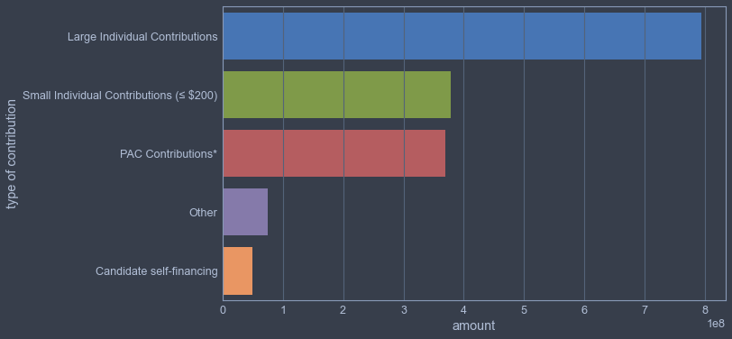

|  | type of contribution | amount | proportion |
| --- | --- | --- | --- |
| 1 | Large Individual Contributions | 794772493 | 0.476499 |
| 4 | Small Individual Contributions (≤ $200) | 377748710 | 0.226476 |
| 3 | PAC Contributions* | 370225791 | 0.221966 |
| 2 | Other | 75481464 | 0.045254 |
| 0 | Candidate self-financing | 49711634 | 0.029804 |

## Is there any detectable difference in contribution sources between Democrat and Republican?

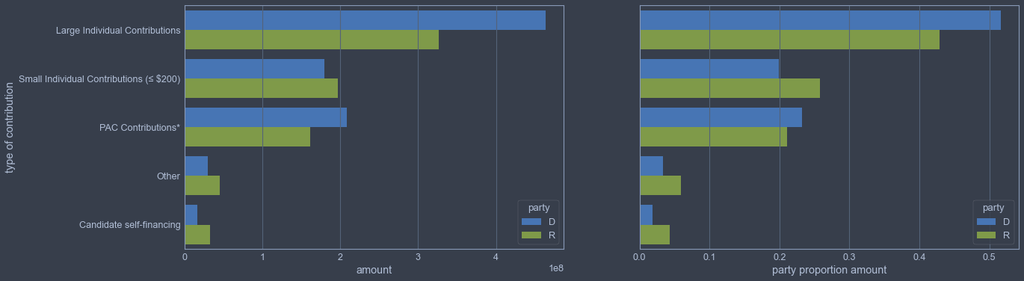

## Do the funding sources from the winning candidate or incumbent candidate differ from the other candidates?

### Winner vs Losers (for lack of a better word)

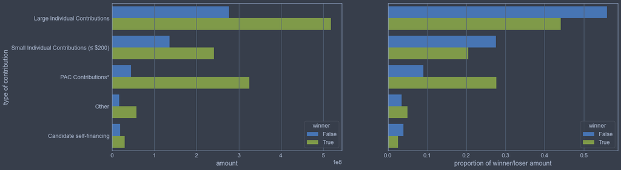

### Incumbent vs Challengers (for lack of a better word)

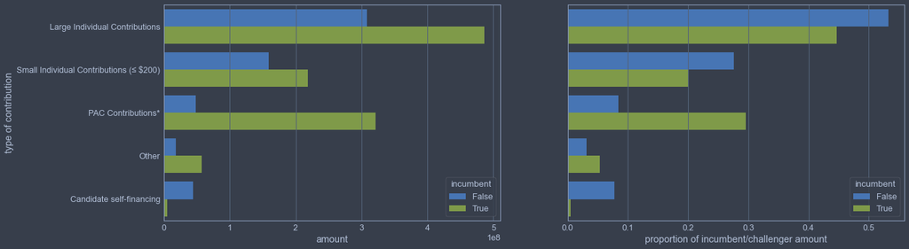